# Top Youtubers and Trending Videos Analysis

Group 8: Xu Li, Yo-Wen Chang, Peixin Lin, Ruiying Liang, Runqing Liu, Hans Yan, Kok Kent Chong

[figure not shown]

# Introduction

YouTube is an American online video-sharing and social media platform owned by Google. It is the world’s most popular and most used video platform today, with more than one billion monthly users who collectively watch more than one billion hours of videos each day.

YouTube has had an unprecedented social impact, influencing popular culture and internet trends and creating multimillionaire celebrities. To get an insight into the trending culture and topics, we will analyze the dataset of most subscribed YouTube channels, including categories, number of subscribers and views, etc. In addition, YouTube has a list of trending videos that is updated constantly, which we could use to take one more step in analyzing its trending videos to see what is typical between them. On the other hand, these insights could also be useful for creators who want to increase the popularity of their videos on YouTube.

Our analytics focus on three key topics: 1)Engagement difference by Youtubers’ nationalities & categories 2)Viewers’ negative sentiment by their countries & videos categories 3)Viewership Habits by Countries

Characteristics of trending videos or youtubers are carefully examined with insights and findings summarized in the end.

[output not shown]

# Dataset1 Import and Preprocessing

## Data Description

```r
#load data
youtuber <- read.csv("youtube200.csv", header=T)
head(youtuber)
```

```
##   Country               ChannelName      Category MainVideoCategory
## 1      IN                  T-Series Gaming & Apps             Music
## 2      US ABCkidTV - Nursery Rhymes Gaming & Apps         Education
## 3      IN                 SET India Gaming & Apps             Shows
## 4      US                 PewDiePie Gaming & Apps            Gaming
## 5      US                   MrBeast Gaming & Apps     Entertainment
## 6      US               Like Nastya                  People & Blogs
##                    username followers     Maintopic CountTopics        Topic1
## 1                  T-Series 220000000 Music of Asia           4 Entertainment
## 2 ABCkidTV - Nursery Rhymes 138000000        Movies           3 Entertainment
## 3                 SET India 137000000        Movies           4 Entertainment
## 4                 PewDiePie 111000000     Lifestyle           4        Gaming
## 5                   MrBeast  98100000     Lifestyle           3 Entertainment
## 6               Like Nastya  97300000         Hobby           2     Lifestyle
##          Topic2     Topic3                Topic4 Topic5 Topic6 Topic7 Topic8
```

[output cut: 27 more lines]

```r
#data description
describe(youtuber)
```

```
##                      vars   n         mean           sd       median
## Country*                1 200 1.640000e+01 1.030000e+01 1.500000e+01
## ChannelName*            2 200 9.950000e+01 5.787000e+01 9.950000e+01
## Category*               3 200 4.140000e+00 1.890000e+00 4.000000e+00
## MainVideoCategory*      4 200 7.420000e+00 2.920000e+00 7.500000e+00
## username*               5 200 9.950000e+01 5.787000e+01 9.950000e+01
## followers               6 200 3.947750e+07 2.262278e+07 3.255000e+07
## Maintopic*              7 200 1.163000e+01 5.230000e+00 1.200000e+01
## CountTopics             8 200 3.000000e+00 1.090000e+00 3.000000e+00
## Topic1*                 9 200 6.860000e+00 3.550000e+00 8.000000e+00
## Topic2*                10 200 9.240000e+00 4.670000e+00 1.000000e+01
## Topic3*                11 200 8.350000e+00 6.650000e+00 5.500000e+00
## Topic4*                12 200 2.730000e+00 3.420000e+00 1.000000e+00
## Topic5*                13 200 1.360000e+00 1.510000e+00 1.000000e+00
## Topic6*                14 200 1.050000e+00 3.900000e-01 1.000000e+00
## Topic7*                15 200 1.000000e+00 7.000000e-02 1.000000e+00
## Topic8*                16 200 1.000000e+00 7.000000e-02 1.000000e+00
## Likes                  17 200 1.813016e+08 3.084215e+08 7.041162e+07
## BoostIndex             18 200 6.497000e+01 1.649000e+01 7.000000e+01
## EngagementRate         19 199 4.600000e-01 1.070000e+00 1.200000e-01
## EngagementRate60days   20 200 8.000000e-02 1.800000e-01 3.000000e-02
## Views                  21 200 2.070922e+10 2.126891e+10 1.631175e+10
## ViewsAvg               22 199 1.663930e+07 4.082130e+07 2.911653e+06
## Avg1Day                23 117 1.653715e+05 4.385792e+05 2.630938e+04
## Avg3Day                24 153 4.580053e+05 9.845389e+05 7.633722e+04
## Avg7Day                25 172 9.767794e+05 2.721150e+06 1.495268e+05
## Avg14Day               26 182 1.744766e+06 6.046917e+06 2.505723e+05
## Avg30day               27 191 2.190457e+06 6.533621e+06 3.817325e+05
## Avg60day               28 200 2.714340e+06 7.017056e+06 5.394513e+05
## CommentsAvg            29 199 1.373315e+04 2.960144e+04 1.209180e+03
## YoutubeLink*           30 200 1.005000e+02 5.788000e+01 1.005000e+02
##                           trimmed          mad        min          max
## Country*             1.687000e+01 1.927000e+01 1.0000e+00 2.800000e+01
## ChannelName*         9.950000e+01 7.413000e+01 1.0000e+00 1.990000e+02
## Category*            4.180000e+00 2.970000e+00 1.0000e+00 9.000000e+00
## MainVideoCategory*   7.240000e+00 2.220000e+00 1.0000e+00 1.700000e+01
## username*            9.950000e+01 7.413000e+01 1.0000e+00 1.990000e+02
## followers            3.475688e+07 9.414510e+06 2.4000e+07 2.200000e+08
## Maintopic*           1.132000e+01 4.450000e+00 1.0000e+00 2.400000e+01
## CountTopics          2.980000e+00 1.480000e+00 0.0000e+00 8.000000e+00
```

[output cut: 38 more lines]

```
## Topic8*              1.000000e+00 13.93   193.03 0.000000e+00
## Likes                2.191406e+09  3.50    15.06 2.180869e+07
## BoostIndex           8.700000e+01 -1.48     2.05 1.170000e+00
## EngagementRate       1.058000e+01  5.89    44.76 8.000000e-02
## EngagementRate60days 1.520000e+00  5.45    35.50 1.000000e-02
## Views                1.960000e+11  4.51    27.85 1.503939e+09
## ViewsAvg             4.239228e+08  6.09    50.62 2.893745e+06
## Avg1Day              3.472638e+06  4.85    28.56 4.054666e+04
## Avg3Day              6.596001e+06  3.64    15.33 7.959525e+04
## Avg7Day              2.994102e+07  7.48    72.65 2.074858e+05
## Avg14Day             6.877732e+07  8.38    83.64 4.482273e+05
## Avg30day             6.877732e+07  6.87    58.95 4.727562e+05
## Avg60day             5.383523e+07  5.09    29.90 4.961808e+05
## CommentsAvg          1.995235e+05  3.32    12.46 2.098390e+03
## YoutubeLink*         1.990000e+02  0.00    -1.22 4.090000e+00
```

## Missing Values Checking

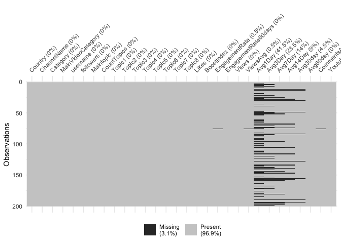

```r
vis_miss(youtuber)
```

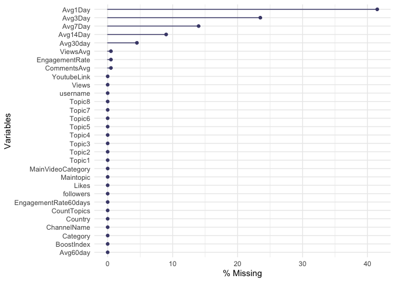

```r
gg_miss_var(youtuber,show_pct = TRUE)
```

```r
#Missing data
pct_miss(youtuber) #overall percent of missing data
```

```
## [1] 3.133333
```

```r
pct_miss(youtuber$Avg1Day)
```

```
## [1] 41.5
```

```r
pct_miss(youtuber$Avg3Day)
```

```
## [1] 23.5
```

```r
pct_miss(youtuber$Avg7Day)
```

```
## [1] 14
```

```r
pct_miss(youtuber$Avg14Day)
```

```
## [1] 9
```

The percentages of missing data in Avg1Day and Avg3Day is higher than 20%, especially for Avg1Day.These two variables are not suitable for further analysis as the percentages of missing data is high, making attempt to impute values will not make much sense.

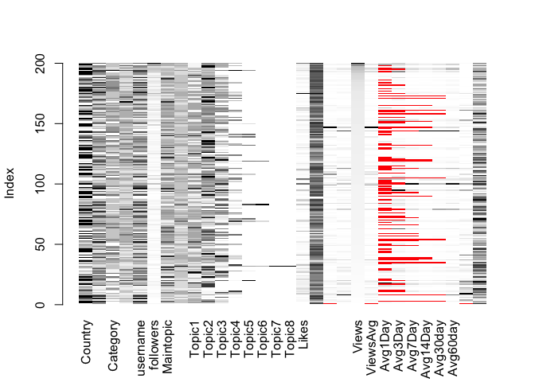

```
##
## Click in a column to sort by the corresponding variable.
## To regain use of the VIM GUI and the R console, click outside the plot region.
```

```r
matrixplot(youtuber, sortby = "Views")
```

Here, the black and white variables represent a heatmap of values within each column, and red indicates a missing value. This can be useful for identifying if missing patterns are dependent on observed data values. It seems there is no distinct pattern for the missing values.

# Descriptive Statistics

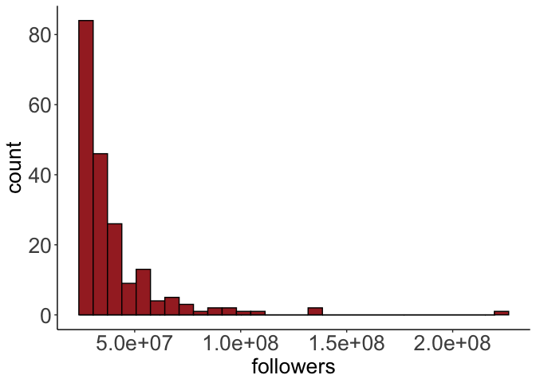

```r
ggplot(youtuber, aes(x=followers)) +
 geom_histogram(aes(y=..count..), colour="black", fill="#A52A2A")+
 geom_density(alpha=.2, fill="#FF6666")+ scale_x_continuous(labels = function(x) format(x, scientific = TRUE))+theme_classic()+theme(axis.text = element_text(size = 20),axis.title = element_text(size = 20))
```

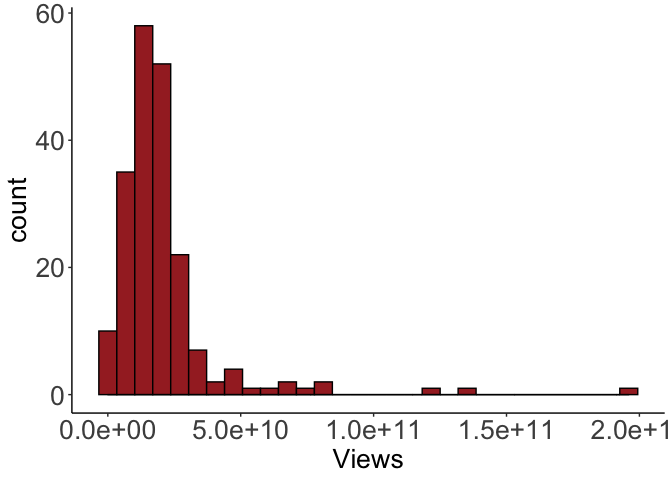

```r
ggplot(youtuber, aes(x=Views)) +
 geom_histogram(aes(y=..count..), colour="black", fill="#A52A2A")+
 geom_density(alpha=.2, fill="#FF6666")+ scale_x_continuous(labels = function(x) format(x, scientific = TRUE))+theme_classic()+theme(axis.text = element_text(size = 20),axis.title = element_text(size = 20))
```

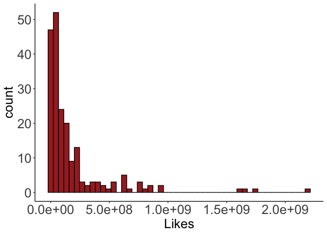

```r
ggplot(youtuber, aes(x=Likes)) +
geom_histogram(aes(y=..count..), colour="black", fill="#A52A2A", bins = 50)+ scale_x_continuous(labels = function(x) format(x, scientific = TRUE))+
theme_classic()+theme(axis.text = element_text(size = 20),axis.title = element_text(size = 20))
```

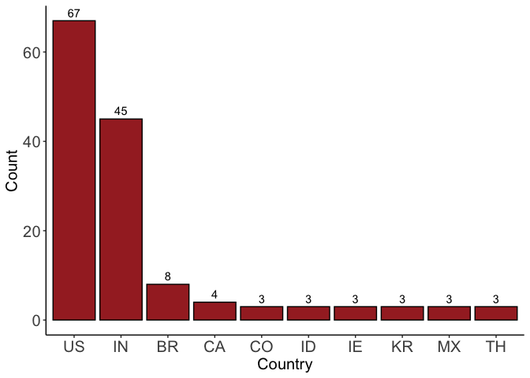

```r
# remove column if the country column is empty
youtuber_country = youtuber[!(is.na(youtuber$Country) | youtuber$Country==""), ]
# top 200 youtubers by country
topyoutuber_country =
  youtuber_country %>%
  head(200)  %>%
  group_by(Country) %>%
  summarize( Count=n()
             ,Percent=round(Count/nrow(.)*100,digits=2)
           ) %>%
  arrange(desc(Count)) %>%
  head(10)

ggplot(topyoutuber_country, aes(x = reorder(Country,-Count), y = Count)) +
    geom_bar(stat="identity", color='black',fill='#A52A2A')+
    geom_text(aes(label=Count), vjust = -0.5, colour = "black") +
    scale_x_discrete(name ="Country") +
    theme_classic()+theme(axis.text = element_text(size = 15),axis.title = element_text(size = 15))
```

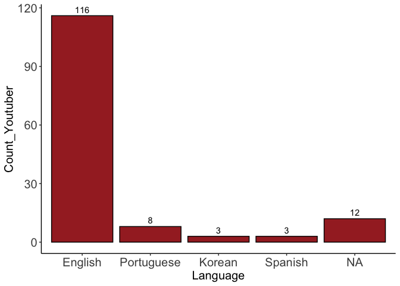

```r
# create language dataframe
language = data.frame (
  countrylist  = c("US","IN","BR","KR","MX","RU","BY","CA","CL","NO"),
  Language = c("English","English","Portuguese","Korean","Spanish","Russian","Russian","English","Spanish","Norwegian")
)

# join the language with the country and display the result in the bar chart
topyoutuber_country %>%
  left_join(language,by = c("Country" = "countrylist")) %>%
  group_by(Language) %>%
  summarize( Count_Youtuber=sum(Count)) %>%
  arrange(desc(Count_Youtuber)) %>%
  ggplot(aes(x = reorder(Language,-Count_Youtuber), y = Count_Youtuber)) +
    geom_bar(stat="identity", color='black',fill='#A52A2A')+
    geom_text(aes(label=Count_Youtuber), vjust = -0.5, colour = "black") +
    scale_x_discrete(name ="Language") +
    theme_classic()+theme(axis.text = element_text(size = 15),axis.title = element_text(size = 15))
```

According to the findings, top2 countries for top200 youtubers are Indian and US. Moreover, creating channels in English-speaking countries is more likely to reach a global audience.

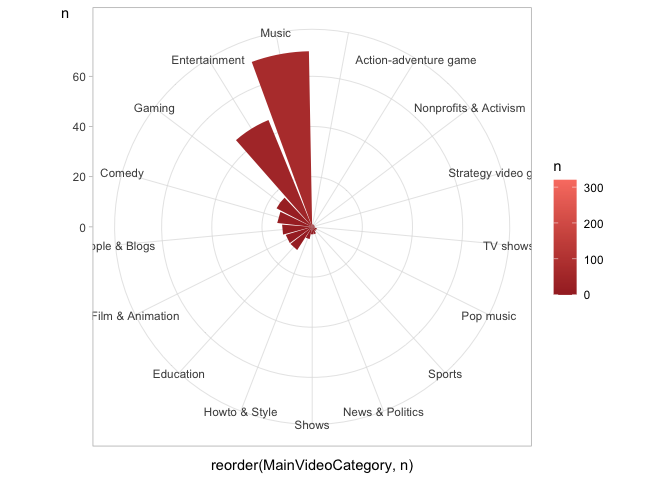

```r
df <- youtuber %>%
  group_by(MainVideoCategory) %>% # Variable to be transformed
  count() %>%
  ungroup() %>%
  mutate(perc = `n` / sum(`n`)) %>%
  arrange(perc) %>%
  mutate(labels = scales::percent(perc))

ggplot(df, aes(x = MainVideoCategory, y = n, fill = n)) +
    geom_bar(binwidth=1, stat="identity") +theme_light() +
    scale_fill_gradient(low="#A52A2A", high="#FA8072",limits=c(0,320)) +
    theme(axis.title.y=element_text(angle=0))+
    coord_polar()+
    aes(x=reorder(MainVideoCategory, n))
```

More than 50% of the top 200 Youtubers fall under the category of “Music” and “Entertainment”, with gaming coming third.

# Key Topic 1:Engagement difference by Youtubers’ nationalities & categories

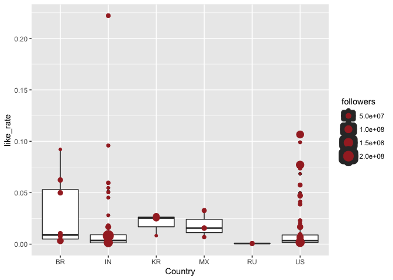

```r
youtuber$like_rate=youtuber$Likes/youtuber$Views
youtuber_top_country<- youtuber %>%
 filter(Country=='US'|Country=='IN'|Country=='BR'|Country=='KR'|Country=='MX'|Country=='RU') %>%
 select_all()
ggplot(data=youtuber_top_country,aes(x=Country, y=like_rate, size=followers))+geom_boxplot()+geom_point(color='#A52A2A')
```

The like rate distribution by countries is skewed to the lower level with only a few distinguished youtubers (outliers) with higher like rate.Besides that, many youtubers with a higher like-rate have less followers.

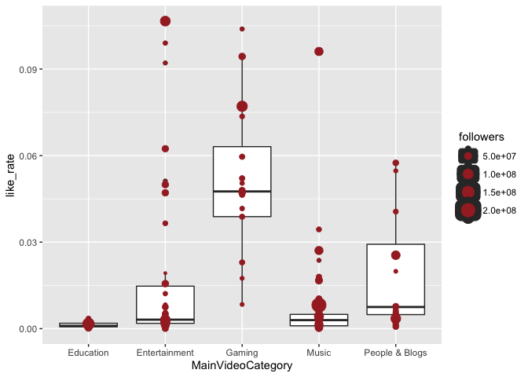

```r
options(repr.plot.width=15, repr.plot.height=8)
youtuber_top_Cate<- youtuber %>%
 filter(MainVideoCategory=='Music'| MainVideoCategory=='Entertainment'|MainVideoCategory=='Education'|MainVideoCategory=='Gaming'|MainVideoCategory=='People & Blogs') %>%
 select_all()

ggplot(data=youtuber_top_Cate,aes(x=MainVideoCategory, y=like_rate, size=followers))+geom_boxplot()+geom_point(color='#A52A2A')
```

Among the top 5 categories, the categories with highest like rate are Gaming videos, which is also with a high variance in like rate. The category with lowest average like rate are ducation videos, whose distribution is relatively concentrated (small variance)

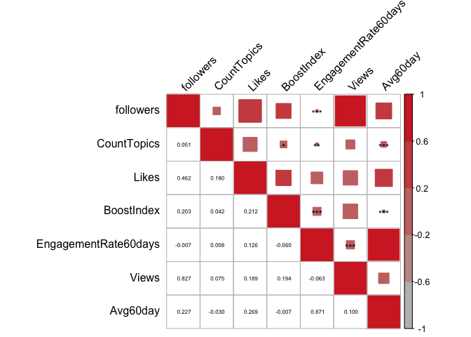

```r
library(corrplot)
options(repr.plot.width=16, repr.plot.height=16)
youtuber_numeric<-youtuber[,c(6,8,17:29)]
youtuber_numeric<-youtuber_numeric[,colSums(is.na(youtuber_numeric))==0]
cor_data<-cor(youtuber_numeric)
corrplot(corr =cor_data, p.mat = cor_data,method = "square",
         type="upper",
         tl.pos="lt", tl.cex=1, tl.col="black",tl.srt = 45,tl.offset=0.5,
         insig="label_sig",sig.level = c(.001, .01, .05),
         pch.cex = 0.8,pch.col = "black",col = colorRampPalette(c("grey", "#D22B2B"))(5))
corrplot(corr = cor_data, method = "number",
         type="lower",add=TRUE,
         tl.pos = "n",cl.pos = "n",diag=FALSE,
         number.digits = 3,number.cex = 0.5,col = "black",number.font = NULL)
```

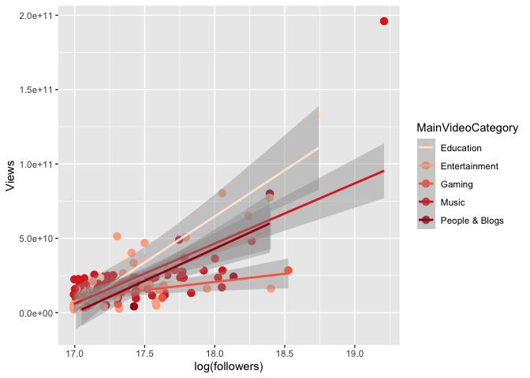

```r
options(repr.plot.width=10, repr.plot.height=8)
ggplot(data=youtuber_top_Cate,aes(x=log(followers), y=Views, color=MainVideoCategory))+geom_point(size=3)+
  stat_smooth(method='lm',formula=y~x)+scale_color_brewer(palette='Reds')
```

```
## Warning in qt((1 - level)/2, df): NaNs produced

## Warning in max(ids, na.rm = TRUE): no non-missing arguments to max; returning
## -Inf
```

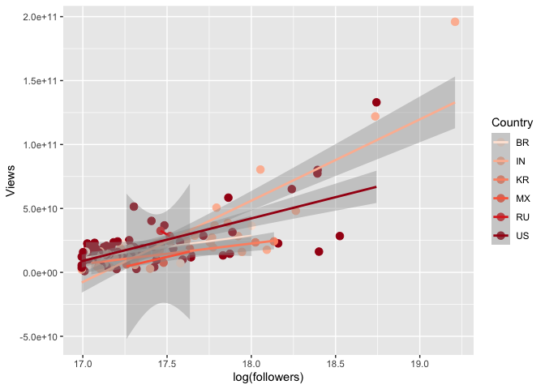

```r
options(repr.plot.width=10, repr.plot.height=8)
ggplot(data=youtuber_top_country,aes(x=log(followers), y=Views, color=Country))+geom_point(size=3)+geom_smooth(method='lm')+scale_color_brewer(palette='Reds')
```

```r
#anova
ano_cate<-aov(Views/log(followers)~MainVideoCategory,data=youtuber_top_Cate)
summary(ano_cate)
```

```
##                    Df    Sum Sq   Mean Sq F value Pr(>F)
## MainVideoCategory   4 8.876e+18 2.219e+18    1.75  0.142
## Residuals         150 1.902e+20 1.268e+18
```

```r
ano_cty<-aov(Views/log(followers)~Country,data=youtuber_top_country)
summary(ano_cty)
```

```
##              Df    Sum Sq   Mean Sq F value Pr(>F)
## Country       5 3.175e+18 6.349e+17    0.35  0.882
## Residuals   122 2.216e+20 1.817e+18
```

# Dataset2 Import and Preprocessing

## Data Loading

Our original data consists of 5 different videos collected from Kaggle. US_raw, GB_raw, CA_raw and IN_raw are the records of trending videos in United States, Great British, Canada and India respectively. Dataframe youtuber consists the information about the top 200 most popular youtubers. Besides, our original data only contain a categoryID but miss the name of each category, it is essential to find what category each categroyID is corresponding to. For that purpose, other four json files are also read.

```r
#read csv
US_raw <- read.csv("US_youtube_trending_data.csv")
GB_raw <- read.csv("GB_youtube_trending_data.csv")
CA_raw <- read.csv("CA_youtube_trending_data.csv")
IN_raw <- read.csv("IN_youtube_trending_data.csv")
youtuber <- read.csv("top_200_youtubers.csv")

#read json
us_cat_name <- fromJSON("US_category_id.json")
gb_cat_name <- fromJSON("GB_category_id.json")
ca_cat_name <- fromJSON("CA_category_id.json")
in_cat_name <- fromJSON("IN_category_id.json")
```

```r
US <- US_raw
GB <- GB_raw
CA <- CA_raw
IN <- IN_raw

#drop irrelevant columns
US <- subset(US, select = -c(video_id, channelId,thumbnail_link,description))
GB <- subset(GB, select = -c(video_id, channelId,thumbnail_link,description))
CA <- subset(CA, select = -c(video_id, channelId,thumbnail_link,description))
IN <- subset(IN, select = -c(video_id, channelId,thumbnail_link,description))

#add country column
US[,"country"] <- "US"
GB[,"country"] <- "GB"
CA[,"country"] <- "CA"
IN[,"country"] <- "IN"

#date time format
US$publishedAt <- ymd_hms(US$publishedAt)
US$trending_date <- ymd_hms(US$trending_date)
GB$publishedAt <- ymd_hms(GB$publishedAt)
GB$trending_date <- ymd_hms(GB$trending_date)
CA$publishedAt <- ymd_hms(CA$publishedAt)
CA$trending_date <- ymd_hms(CA$trending_date)
IN$publishedAt <- ymd_hms(IN$publishedAt)
IN$trending_date <- ymd_hms(IN$trending_date)
```

```r
#Match Category names to Category IDs from US_category_id.json file

#extract ids of categories into a vector
list <- us_cat_name[["items"]]
items <- length(list)

US$categoryId <- as.character(US$categoryId)
ids <- numeric(items)
for(i in seq_along(list)){
  ids[i] <- us_cat_name[["items"]][[i]][[3]]
}

#extract names of categories into a vector
names <- character(items)
for(i in seq_along(list)){
  names[i] <- us_cat_name[["items"]][[i]][[4]][[1]]
}

#join dataframe with category name and drop categoryId
cat <- as.data.frame(cbind(ids,names))
US <- US %>%
  left_join(cat, by=c("categoryId"="ids")) %>%
  dplyr::rename("category"="names") %>%
  select(-categoryId)
```

```r
#Match Category names to Category IDs from GB_category_id.json file

#extract ids of categories into a vector
gb_list <- gb_cat_name[["items"]]
gb_items <- length(gb_list)

GB$categoryId <- as.character(GB$categoryId)
gb_ids <- numeric(gb_items)
for(i in seq_along(gb_list)){
  gb_ids[i] <- gb_cat_name[["items"]][[i]][[3]]
}

#extract names of categories into a vector
gb_names <- character(gb_items)
for(i in seq_along(gb_list)){
  gb_names[i] <- gb_cat_name[["items"]][[i]][[4]][[1]]
}

#join dataframe with category name and drop categoryId
gb_cat <- as.data.frame(cbind(gb_ids,gb_names))
gb_cat[nrow(gb_cat)+1,]=c(29,"Nonprofits & Activism")
GB <- GB %>%
  left_join(gb_cat, by=c("categoryId"="gb_ids")) %>%
  dplyr::rename("category"="gb_names") %>%
  select(-categoryId)
```

```r
#Match Category names to Category IDs from CA_category_id.json file

#extract ids of categories into a vector
ca_list <- ca_cat_name[["items"]]
ca_items <- length(ca_list)

CA$categoryId <- as.character(CA$categoryId)
ca_ids <- numeric(ca_items)
for(i in seq_along(ca_list)){
  ca_ids[i] <- ca_cat_name[["items"]][[i]][[3]]
}

#extract names of categories into a vector
ca_names <- character(ca_items)
for(i in seq_along(ca_list)){
  ca_names[i] <- ca_cat_name[["items"]][[i]][[4]][[1]]
}

#join dataframe with category name and drop categoryId
ca_cat <- as.data.frame(cbind(ca_ids,ca_names))
ca_cat[nrow(ca_cat)+1,]=c(29,"Nonprofits & Activism")
CA <- CA %>%
  left_join(ca_cat, by=c("categoryId"="ca_ids")) %>%
  dplyr::rename("category"="ca_names") %>%
  select(-categoryId)
```

```r
#Match Category names to Category IDs from IN_category_id.json file

#extract ids of categories into a vector
in_list <- in_cat_name[["items"]]
in_items <- length(in_list)

IN$categoryId <- as.character(IN$categoryId)
in_ids <- numeric(in_items)
for(i in seq_along(in_list)){
  in_ids[i] <- in_cat_name[["items"]][[i]][[3]]
}

#extract names of categories into a vector
in_names <- character(in_items)
for(i in seq_along(in_list)){
  in_names[i] <- in_cat_name[["items"]][[i]][[4]][[1]]
}

#join dataframe with category name and drop categoryId
in_cat <- as.data.frame(cbind(in_ids,in_names))
in_cat[nrow(in_cat)+1,]=c(29,"Nonprofits & Activism")
IN <- IN %>%
  left_join(in_cat, by=c("categoryId"="in_ids")) %>%
  dplyr::rename("category"="in_names") %>%
  select(-categoryId)
```

```r
#Add a column indicating if the trending video is created by the top 200 youtubers
US$top200youtuber <- FALSE
US[which(US$channelTitle %in% youtuber$Channel.Name),]$top200youtuber <- TRUE

GB$top200youtuber <- FALSE
GB[which(GB$channelTitle %in% youtuber$Channel.Name),]$top200youtuber <- TRUE

CA$top200youtuber <- FALSE
CA[which(CA$channelTitle %in% youtuber$Channel.Name),]$top200youtuber <- TRUE

IN$top200youtuber <- FALSE
IN[which(IN$channelTitle %in% youtuber$Channel.Name),]$top200youtuber <- TRUE
```

```r
#union 4 datasets toether
ALL = rbind(CA,US,GB,IN)
```

```r
#Distinct data, delete duplicated titles which stayed on the trending list for days
ALL <- ALL %>%
  group_by(title,publishedAt,channelTitle,category,country,tags,comments_disabled,top200youtuber) %>%
  distinct() %>%
  summarize(trendingtimes = n(),
            likes=max(likes),
            dislikes=max(dislikes),
            view_count=max(view_count),
            comment_count=max(comment_count))
```

[output not shown]

```r
# convert comments_disabled true/false into 1/0
ALL <- ALL %>%
  mutate(comments_disabled, disabled = ifelse(comments_disabled=="True", 1, 0))

head(ALL)
```

```
## # A tibble: 6 × 14
## # Groups:   title, publishedAt, channelTitle, category, country, tags,
## #   comments_disabled [6]
##   title publishedAt         channelTitle category country tags  comments_disabl…
##   <chr> <dttm>              <chr>        <chr>    <chr>   <chr> <chr>
## 1 " @S… 2022-10-09 10:32:54 Infinitum N… Enterta… IN      shan… False
## 2 " 🔥… 2021-11-06 04:21:40 bxrry shorts Gaming   CA      shor… False
## 3 " 🔥… 2021-11-06 04:21:40 bxrry shorts Gaming   US      shor… False
## 4 " 🔥… 2022-03-08 21:42:07 bxrry shorts Gaming   CA      shor… False
## 5 " 🔥… 2022-03-08 21:42:07 bxrry shorts Gaming   US      shor… False
## 6 " 20… 2021-08-20 11:29:53 Ponmutta Me… Enterta… IN      ponm… False
## # … with 7 more variables: top200youtuber <lgl>, trendingtimes <int>,
## #   likes <int>, dislikes <int>, view_count <int>, comment_count <int>,
## #   disabled <dbl>
```

# Key topic 2: Viewers’ negative sentiment by their countries & videos categories

```r
# dislike percentage
ALL$dislikePerc <- 0
ALL[which(ALL$likes!=0),] <- ALL[which(ALL$likes!=0),] %>%
  mutate(dislikePerc = dislikes/(likes+dislikes))

# group by category
groupedVideos <- ALL %>%
              group_by(category) %>%
              summarize("dislikePercMean" = mean(dislikePerc),
                        "disabledPercMean" = mean(disabled))

# group by category and country
groupedVideos2 <- ALL %>%
              group_by(category,country) %>%
              summarize("Dislike Percentage" = mean(dislikePerc),
                        "Comments-disabled Percentage" = mean(disabled))
```

Next, we want to visualize the grouped dataset we just created to unlock insight of how negative sentiment vary across video categories and trending list countries.

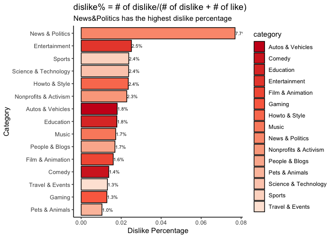

```r
# create color palette
coul <- brewer.pal(4, "Reds")
coul <- colorRampPalette(coul)(15)
coul <- rev(coul)

# plot "Dislike Percentage by Category and Country"
ggplot(groupedVideos, aes(dislikePercMean, reorder(category, dislikePercMean), fill = category, label=percent(dislikePercMean,accuracy=0.1))) +
  geom_bar(col = "black", stat = "identity") +
  scale_fill_manual(values=coul) +
  #geom_line(aes(viewMean, reorder(category, dislikePercMean)), group = 1, lwd = 1, lty = 3, col="grey") +
  labs(y = "Category",
       x = "Dislike Percentage",
       title='dislike% = # of dislike/(# of dislike + # of like)',
       subtitle='News&Politics has the highest dislike percentage') +
  geom_text(hjust = -0.02, size=2.5) +
  theme_classic()
```

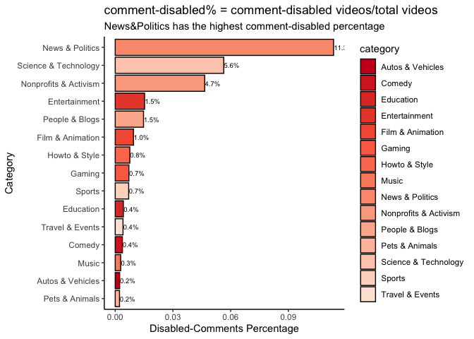

```r
#ggsave("1.png",width = 8,height = 5)

# plot "Disabled-Comments Percentage by Category and Country"
ggplot(groupedVideos, aes(disabledPercMean, reorder(category, disabledPercMean), fill = category, label=percent(disabledPercMean,accuracy=0.1))) +
  geom_bar(col = "black", stat = "identity") +
  scale_fill_manual(values=coul) +
  labs(y = "Category",
       x = "Disabled-Comments Percentage",
       title='comment-disabled% = comment-disabled videos/total videos',
       subtitle='News&Politics has the highest comment-disabled percentage') +
  geom_text(hjust = -0.02, size=2.5) +
  theme_classic()
```

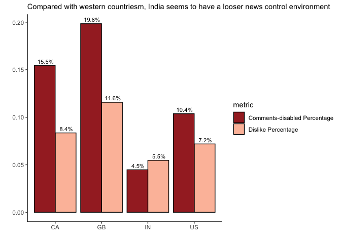

```r
#ggsave("2.png",width = 8,height = 5)


#country difference
subset <- groupedVideos2 %>%
  filter(category == c("News & Politics")) %>%
  gather(metric, value, "Dislike Percentage":"Comments-disabled Percentage" )


ggplot(subset, aes(country, value, fill = metric, label=percent(value,accuracy=0.1))) +
  geom_bar(position="dodge", col = "black", stat = "identity") +
  scale_fill_manual(values=c("#A52A2A","#FCBFA8")) +
  geom_text(position = position_dodge2(width = 0.9),hjust = 0.45,vjust=-0.5, size=3) +
  labs(y = "",
       x = "",
       subtitle="Compared with western countriesm, India seems to have a looser news control environment")+
  theme_classic()
```

```r
#ggsave("3.pdf",width = 8,height = 6)
```

Based on the above pictures, we found that News&Politics is the category where negative sentiment dwell most and news control environment differ from each country. Thus, we decided to dive deeper into the category of News&Politics to explore the different attitudes News&Politics in different country.

```r
#define a function which can generate a wordcloud

freqWord = function(df,categ,country,remove) {
docs = Corpus(VectorSource(df[(df$category == categ)&(df$country==country),]$tags))

toSpace <- content_transformer(function (x , pattern ) gsub(pattern, " ", x))
docs <- tm_map(docs, toSpace, "/")
docs <- tm_map(docs, toSpace, "@")
docs <- tm_map(docs, toSpace, "\\|")
# Convert the text to lower case
docs <- tm_map(docs, content_transformer(tolower))
# Remove numbers
docs <- tm_map(docs, removeNumbers)
# Remove english common stopwords
docs <- tm_map(docs, removeWords, stopwords("english"))
docs <- tm_map(docs, removeWords, remove)
# Remove your own stop word
# specify your stopwords as a character vector
# docs <- tm_map(docs, removeWords, c("des", "les", "pas", "de", "est", "plus", "vos"))
# Remove punctuations
docs <- tm_map(docs, removePunctuation)
# Eliminate extra white spaces
docs <- tm_map(docs, stripWhitespace)
# Text stemming
# docs <- tm_map(docs, stemDocument)
dtm <- TermDocumentMatrix(docs)
m <- as.matrix(dtm)
v <- sort(rowSums(m),decreasing=TRUE)
d <- data.frame(word = names(v),freq=v)

wordcloud(words = d$word, freq = d$freq,min.freq = 20,
          max.words=100, random.order=FALSE, rot.per=0.35,
          scale=c(3.2,0.4),
          colors=c("#282828","#FF0000"))
#wordcloud2(d,color="#FF0000",
           #backgroundColor = "#282828")
}
```

[figure not shown]

```r
negative <- ALL %>%
  filter(dislikePerc > 0.10)
freqWord(negative,'News & Politics','US',c('news','today'))
```

The most controversial topic in the US is about election

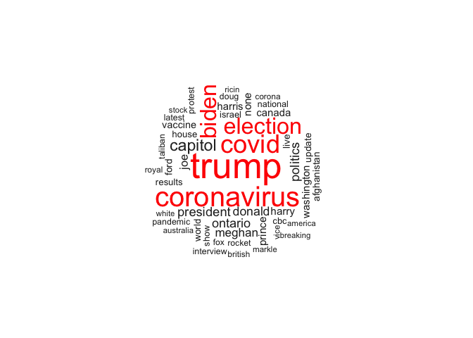

```r
freqWord(negative,'News & Politics','CA',c('news','today'))
```

The result of Canada is between US and GB.

[figure not shown]

```r
freqWord(negative,'News & Politics','GB',c('news','today'))
```

The most controversial topic in GB is about coronavirus.

[figure not shown]

```r
freqWord(negative,'News & Politics','IN',c('news','today','live'))
```

## Overlapping number of videos

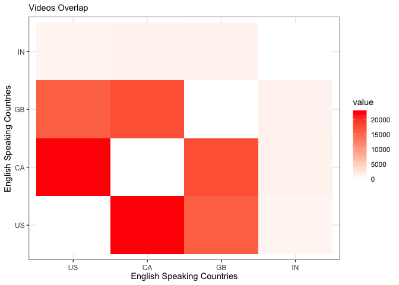

```r
# Heatmap for Video Overlaps between 4 English Speaking Countries: India, United States, Canada & United Kingdom

countoverlap <- function(country_x, country_y) {
  overlap <- country_x %>%
    inner_join(country_y, by=c("title"="title")) %>%
    distinct(title, .keep_all=TRUE)
  n <- nrow(overlap)
  return(n)
}

countrylst <- list()
countrylst[[1]] <- US
countrylst[[2]] <- CA
countrylst[[3]] <- GB
countrylst[[4]] <- IN

M <- matrix(nrow = 4, ncol = 4)
#count <- df()
for (i in 1:4) {
  for (n in 1:4){
    count <- countoverlap(countrylst[[i]], countrylst[[n]])
    M[i,n] <- count
  }
}
countries <- c("US","CA", "GB", "IN")
count <- data.frame(matrix(ncol=3,nrow=0, dimnames=list(NULL, c("CountryX", "CountryY", "SharedVideos"))))
for (i in 1:4) {
  for (n in 1:4){
    c <- countoverlap(countrylst[[i]], countrylst[[n]])
    count[nrow(count)+1,] = c(countries[i], countries[n], c)
  }
}
M[1,1] = 0
M[2,2] = 0
M[3,3] = 0
M[4,4] = 0
rownames(M) <- c("US", "CA","GB","IN")
colnames(M) <- c("US", "CA","GB","IN")
M.1 <-melt(M)
ggplot(M.1, aes(x = X2, y = X1)) +
  geom_raster(aes(fill=value)) +
  theme_bw() + theme(axis.text.x=element_text(size=9, angle=0, vjust=0.3),
                     axis.text.y=element_text(size=9),
                     plot.title=element_text(size=11)) + scale_fill_gradient(low = "white", high = "#FF0000") +
  labs(x = "English Speaking Countries", y = "English Speaking Countries", title = "Videos Overlap")
```

Evidently, we are able to observe that US and CA has the most overlapping videos, followed by GB while IN has the least overlapping videos, which is quite intuitive due to cultural similarity and geographic distance.

## Commonality -> category: music, game, entertainment

```r
#Join data by title to find all videos which exist on the trending list of all 4 countries
shared <- US %>%
  inner_join(CA, by=c("title"="title")) %>%
  inner_join(GB, by=c("title"="title")) %>%
  inner_join(IN, by=c("title"="title")) %>%
  distinct(title, .keep_all=TRUE)  %>%
  select(1,3,4,5,6,7,8,9,10,11,12,13,14) %>%
  dplyr::rename( channelTitle=channelTitle.x,view_count=view_count.x,likes=likes.x, tags=tags.x,
         dislikes=dislikes.x,comment_count=comment_count.x, category=category.x, top200youtuber=top200youtuber.x)
```

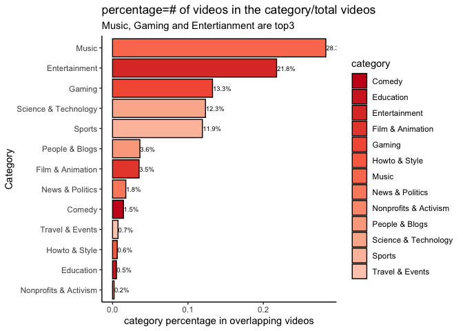

```r
#group overlapping videos by category and compute the percentage
group_cate <- shared %>%
  group_by(category) %>%
  summarize(percentage = n()/nrow(shared))

#plot the above result
ggplot(group_cate, aes(percentage, reorder(category, percentage), fill = category, label=percent(percentage,accuracy=0.1))) +
  geom_bar(col = "black", stat = "identity") +
  scale_fill_manual(values=coul) +
  #geom_line(aes(viewMean, reorder(category, dislikePercMean)), group = 1, lwd = 1, lty = 3, col="grey") +
  labs(y = "Category",
       x = "category percentage in overlapping videos",
       title='percentage=# of videos in the category/total videos',
       subtitle='Music, Gaming and Entertianment are top3') +
  geom_text(hjust = -0.02, size=2.5) +
  theme_classic()
```

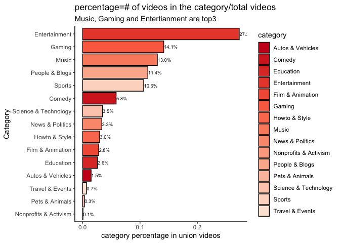

```r
# group union videos by category and compute the percentage
group_cate <- ALL %>%
  group_by(category) %>%
  summarize(percentage = n()/nrow(ALL))

#plot the above result
ggplot(group_cate, aes(percentage, reorder(category, percentage), fill = category, label=percent(percentage,accuracy=0.1))) +
  geom_bar(col = "black", stat = "identity") +
  scale_fill_manual(values=coul) +
  #geom_line(aes(viewMean, reorder(category, dislikePercMean)), group = 1, lwd = 1, lty = 3, col="grey") +
  labs(y = "Category",
       x = "category percentage in union videos",
       title='percentage=# of videos in the category/total videos',
       subtitle='Music, Gaming and Entertianment are top3') +
  geom_text(hjust = -0.02, size=2.5) +
  theme_classic()
```

From the above two pictures, we can see that Music, Entertainment and Gaming are always top 3 no matter in overlapping videos or union videos, but compared with the percentage in union videos, music accounts for a greater percenate abput 28% in overlapping videos while only accounts for 13% in union videos. Music is the most shared category across the world. It might be because that music can arouse resonace more easily.

## wordcould of overlapping videos by category

```r
freqWord1 = function(categ,remove) {
docs = Corpus(VectorSource(shared[shared$category == categ,]$tags))

toSpace <- content_transformer(function (x , pattern ) gsub(pattern, " ", x))
docs <- tm_map(docs, toSpace, "/")
docs <- tm_map(docs, toSpace, "@")
docs <- tm_map(docs, toSpace, "\\|")
# Convert the text to lower case
docs <- tm_map(docs, content_transformer(tolower))
# Remove numbers
docs <- tm_map(docs, removeNumbers)
# Remove english common stopwords
docs <- tm_map(docs, removeWords, stopwords("english"))
docs <- tm_map(docs, removeWords, remove)
# Remove your own stop word
# specify your stopwords as a character vector
# docs <- tm_map(docs, removeWords, c("des", "les", "pas", "de", "est", "plus", "vos"))
# Remove punctuations
docs <- tm_map(docs, removePunctuation)
# Eliminate extra white spaces
docs <- tm_map(docs, stripWhitespace)
# Text stemming
# docs <- tm_map(docs, stemDocument)
dtm <- TermDocumentMatrix(docs)
m <- as.matrix(dtm)
v <- sort(rowSums(m),decreasing=TRUE)
d <- data.frame(word = names(v),freq=v)

wordcloud(words = d$word, freq = d$freq,min.freq = 10,
          max.words=100, random.order=FALSE, rot.per=0.35,
          scale=c(3.2,0.4),
          colors=c("#282828","#FF0000"))
#wordcloud2(d,color="#FF0000",
           #backgroundColor = "#282828")
}
```

```r
group_chan <- shared %>%
  group_by(channelTitle) %>%
  summarize(count = n()) %>%
  arrange(desc(count))


group_chan %>%
  left_join(shared, by=c("channelTitle"="channelTitle")) %>%
  filter(category=="Music") %>%
  select(channelTitle, count, top200youtuber) %>%
  distinct()
```

```
## # A tibble: 50 × 3
##    channelTitle      count top200youtuber
##    <chr>             <int> <lgl>
##  1 Dude Perfect         40 TRUE
##  2 BLACKPINK            32 TRUE
##  3 BANGTANTV            26 TRUE
##  4 HYBE LABELS          26 FALSE
##  5 JYP Entertainment    23 FALSE
##  6 SMTOWN               20 TRUE
##  7 TaylorSwiftVEVO      19 TRUE
##  8 Big Hit Labels       12 FALSE
##  9 BillieEilishVEVO     10 FALSE
## 10 JustinBieberVEVO     10 TRUE
## # … with 40 more rows
```

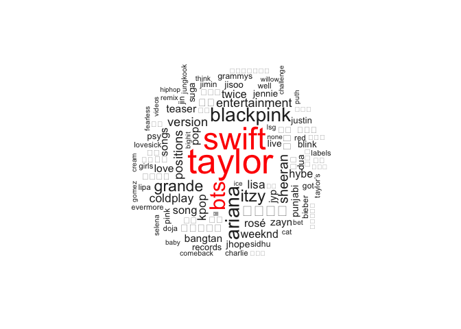

```r
#par(family="AppleGothic")
freqWord1("Music",c("official", "music","video","new","album","lyrics"))
```

We can see English pop music are appearing often on the overlapping trending list, but surprisingly, there are many korean characters all of which are about kpop. Kpop explosion breaks cultural barriers and has become a global phenomenon. Their visual effects involving colourful costumes and perfect dancing are conquering the world.

```r
group_chan <- shared %>%
  group_by(channelTitle) %>%
  summarize(count = n()) %>%
  arrange(desc(count))


group_chan %>%
  left_join(shared, by=c("channelTitle"="channelTitle")) %>%
  filter(category=="Entertainment") %>%
  select(channelTitle, count, top200youtuber) %>%
  distinct()
```

```
## # A tibble: 43 × 3
##    channelTitle                count top200youtuber
##    <chr>                       <int> <lgl>
##  1 MrBeast                        41 TRUE
##  2 Marvel Entertainment           36 FALSE
##  3 ZHC                            30 TRUE
##  4 Warner Bros. Pictures          17 FALSE
##  5 HBO Max                        14 FALSE
##  6 Netflix                        14 TRUE
##  7 Sony Pictures Entertainment     8 FALSE
##  8 Logan Paul                      6 FALSE
##  9 Justin Bieber                   5 TRUE
## 10 OverSimplified                  5 FALSE
## # … with 33 more rows
```

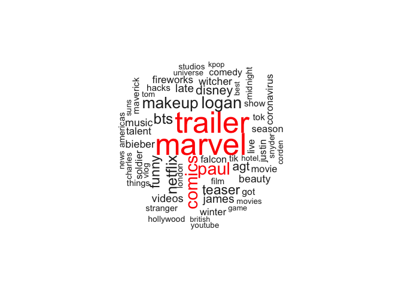

```r
#par(family="AppleGothic")
freqWord1("Entertainment",c("official", "none","video","new","album","lyrics"))
```

There are some entertainment giants appeared in the wordcloud, like Marvel, Netflix and so on. There are also some media personalities,individual content creator whose views and subscribers are comparable to entertainment giants.

```r
group_chan <- shared %>%
  group_by(channelTitle) %>%
  summarize(count = n()) %>%
  arrange(desc(count))


group_chan %>%
  left_join(shared, by=c("channelTitle"="channelTitle")) %>%
  filter(category=="Entertainment") %>%
  select(channelTitle, count, top200youtuber) %>%
  distinct()
```

```
## # A tibble: 43 × 3
##    channelTitle                count top200youtuber
##    <chr>                       <int> <lgl>
##  1 MrBeast                        41 TRUE
##  2 Marvel Entertainment           36 FALSE
##  3 ZHC                            30 TRUE
##  4 Warner Bros. Pictures          17 FALSE
##  5 HBO Max                        14 FALSE
##  6 Netflix                        14 TRUE
##  7 Sony Pictures Entertainment     8 FALSE
##  8 Logan Paul                      6 FALSE
##  9 Justin Bieber                   5 TRUE
## 10 OverSimplified                  5 FALSE
## # … with 33 more rows
```

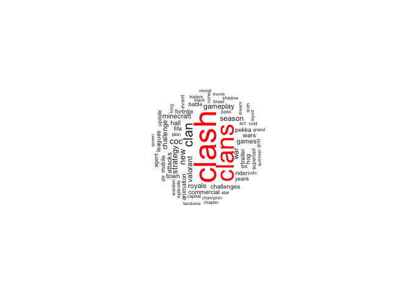

```r
#par(family="AppleGothic")
freqWord1("Gaming",c("game"))
```

As for game, it is surprising that it is clash of clans, a mobile game about kingdom building, other than competitive PC games, bring the most common video content on youtube.

# Conclusion, Limitation and Next steps

## Conlusions

Key Question 2: Viewers’ Negative Sentiment by their Countries and Videos Categories Topics related to politics and covid-19 pandemic exhibit a controversial manner . Western countries share a more common viewership habit compared with India.

Key Question 3: Viewership Habits by English Speaking Countries Music, Entertainment, & Gaming are categories enjoyed by all aforementioned nations. KPop exhibits a rather surprisingly popular fashion in all four nations.

## Limitations

Our sample only includes the most popular videos without any ordinary videos so more comprehensive conclusions could not be drawn. We also ignore the connection between YouTubers and their videos due to want of more features and difficulty of linking two datasets.

## Next Steps

We would like to include more ordinary videos rather than those only coming from the trending list We would like to explore relations between YouTubers and their videos through additional features such as video quality, shooting method, editing technique and etc. Natural Language Processing & Deep Learning